[figure not shown]

# Quantum Dynamic Circuits

## IBM Quantum Spring Challenge 2023

By: Ahmed Almalki

## What is IBM Quantum Challenge

**The IBM Quantum Challenge** is a free `online event` that introduces quantum computing to learners. It features themed exercises on real quantum hardware and is open to all, regardless of experience.

**The Challenge** is divided into four levels of ascending difficulty: `Explorer`, `Adventurer`, `Pioneer`, and `Master`. Each level consists of a series of exercises that introduce participants to different aspects of quantum computing. The exercises are designed to be challenging, but also fun and engaging.

### The benefits of IBM Quantum Challenge:

- Work on `challenging exercises` that will help you develop your skills.
- Connect with other learners and experts in `the quantum community`.
- Get a glimpse of `the future of computing`.

# IBM Quantum Challenge 2023

This year’s challenge focued on **`dynamic circuits`**, a technology that makes it easier to run more-advanced quantum algorithms. This event featured 5 Labs, each with exercises and tutorial content to get you started using Dynamic Circuits.

## Challenge content

- **Lab 1:** Intro to Dynamic Circuits
- **Lab 2:** Quantum Teleportation
- **Lab 3:** Iterative Phase Estimation
- **Lab 4:** Quantum Error Correction
- **Lab 5:** Using a 127-qubit System

# Intro to Dynamic Circuits

**Dynamic circuits** are quantum circuits with mid-circuit measurements, enabling classical feedforward.

**IBM Quantum hardware** recently added support for mid-circuit measurements and reset, but enabling classical feedforward required a substantial redesign of the control systems and software stack. Full support for dynamic circuits was introduced in `2022`.

[figure not shown]

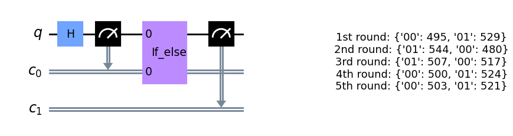

```python
from qiskit import QuantumCircuit
from qiskit.circuit import QuantumRegister, ClassicalRegister

qr = QuantumRegister(1, 'q')
cr = ClassicalRegister(2, 'c')
qc = QuantumCircuit(qr, cr)

qc.h(qr[0])
qc.measure(qr[0], cr[0])

with qc.if_test((cr[0], 1)):
    qc.x(qr[0])

qc.measure(qr[0], cr[1])

# qc.draw(output="mpl")
draw_circuit_and_print_output(qc)
```

# Quantum Teleportation

**Quantum teleportation** is a protocol that allows the transfer of quantum information from one qubit to another using entanglement and classical communication. It was proposed in `1993`.

**The process** does not transmit the qubit itself but rather transfers the quantum state from the source qubit to the target qubit.

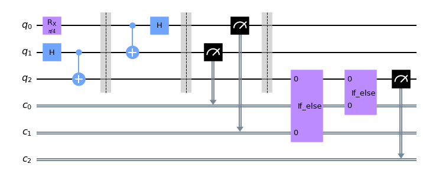

```python
initial_state = initialize_circuit()
initial_state.rx(math.pi/4, 0)

teleportation_circuit = (
    initial_state.compose(bell_pair_circuit)
    .compose(alice_gates_circuit)
    .compose(measure_circuit)
    .compose(bob_gates_circuit)
)

teleportation_circuit.draw(output="mpl")
```

# Output

[figure not shown]

# Iterative Phase Estimation

**Quantum phase estimation (QPE)** is a crucial algorithm used in Shor's factoring algorithm and quantum simulation. However, the textbook version with auxiliary qubits is challenging to execute on current noisy devices.

**Iterative phase estimation (IPE)** is a variant that only needs one auxiliary qubit and was previously impossible to execute on IBM's hardware until `dynamic circuits` were introduced.

# Iterative Phase Estimation

We will perform IPE on the single-qubit $S$-gate. The $S$ gate is given by the matrix

$$ S = \begin{pmatrix} 1 & 0\\ 0 & e^{i\pi / 2} \end{pmatrix}$$

We will use the eigenstate $|\Psi\rangle = |1\rangle$, which has eigenvalue $e^{i\pi / 2}= e^{i2\pi \cdot 1/4}$. So we have $\varphi = 1/4 = 0.01 = 0.\varphi_1 \varphi_2$. Since $\varphi$ can be represented exactly with 2 bits, our quantum circuit implementation will use a classical register with two bits to store the result.

- **Step 1:** We measure the least significant bit of $\varphi_2$.
- **Step 2:** We extract the next bit $\varphi_1$, which will involve applying a phase correction to cancel out the phase contribution from $\varphi_2$.

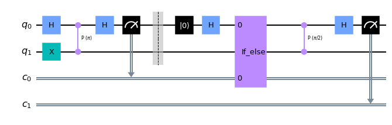

```python
initial_state = initialize_circuit()

IPE_circuit = (
    initial_state.compose(step_1_circuit)
    .compose(step_2_circuit)
)

IPE_circuit.draw(output="mpl")
```

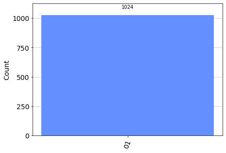

```python
plot_histogram(simulate_circuit(IPE_circuit))
```

We have gotten the bitstring `01` with 100% probability. This value corresponds to the phase written in binary as $\varphi = 0.01 = 1/4$.

# Quantum Error Correction

**Error correction** is vital in quantum computing to address the inevitable errors caused by noise, ensuring accurate results by correcting them as they arise.

**Dynamic circuits** can greatly aid quantum computers in error correction by mitigating noise and ensuring accurate results.

# Quantum Error Correction

Let’s prepare everything such that we can start with implementing the error correction.

- **Initializing the Qubit:** Prepare the physical state $|\Psi_1\rangle = |1\rangle$
- **Encoding the Qubit:** Map our state $|\Psi_1\rangle = (\alpha |0\rangle + \beta |1\rangle)$ using our encoding $U_{en}|\Psi_0\rangle$ to the state $ (\alpha |000\rangle + \beta |111\rangle)$.
- **Measuring Stabilizers:** Compute syndrome bits, such that they can be measured to detect single bitflip errors.
  - `00` -> No error occurred
  - `01` -> An error occurred in qubit 0 (the first qubit)
  - `10` -> An error occurred in qubit 1 (the second qubit)
  - `11` -> An error occurred in qubit 2 (the third qubit)
- **Correcting Errors:** Correct the errors according to the measured syndromes.
- **Decoding Circuit:** Use our decoding $U_{de}|\Psi_0\rangle$ which maps $ (\alpha |000\rangle + \beta |111\rangle)$ to $|\Psi_1\rangle = (\alpha |0\rangle + \beta |1\rangle)$. *Hint:* $U_{de} = U_{en}^\dagger$

```python
initial_state = initialize_circuit()
initial_state.x(encoding[0])

complete_circuit = (
    initial_state.compose(encoding_circuit)
    .compose(noise_circuit) # generating noise 10%
    .compose(syndrome_circuit)
    .compose(correction_circuit)
    .compose(decoding_circuit)
    .compose(measuring_circuit)
)
# complete_circuit.draw(output="mpl")
```

[figure not shown]

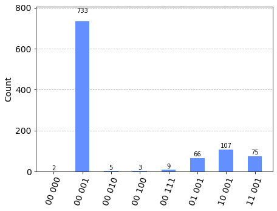

```python
from qiskit import Aer

backend = Aer.get_backend("qasm_simulator")
counts = backend.run(complete_circuit, shots=1000).result().get_counts()
plot_histogram(counts)
```

# Using a 127-qubit System

It was a reward to use one of **`IBM Quantum 127 qubit devices`**

[figure not shown]